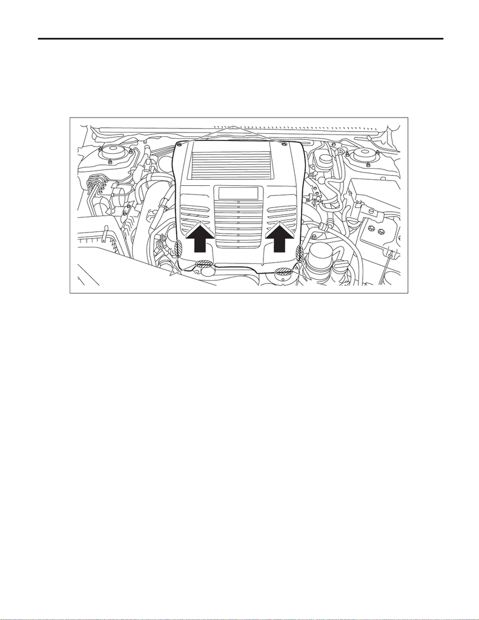

ME(w/o STI)-31

Fuel Pressure

MECHANICAL

7. Fuel Pressure

A: INSPECTION

1) Remove the collector cover.

(1) Remove the clips (A).

(2) Hold the shaded area (B) by hand and carefully pull the RH side (C) upward.

(3) Hold the shaded area (D) by hand and carefully pull the LH side (E) upward.

2) Release the fuel pressure. <Ref. to FU(w/o STI)-146, RELEASING OF FUEL PRESSURE, PROCE-

DURE, Fuel.>

3) Open the fuel filler lid and remove the fuel filler cap.

NOTE:

This operation is required to release the inner pressure of the fuel tank.

EX-03204

(A)

(B)

(C)

(E)

(D)

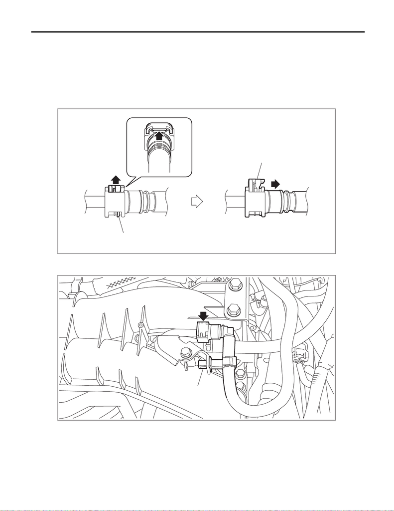

ME(w/o STI)-32

Fuel Pressure

MECHANICAL

4) Disconnect the fuel delivery tube from the fuel delivery pipe, and connect the fuel pressure gauge.

CAUTION:

• Be careful not to spill fuel.

• Catch the fuel from the tubes using a container or cloth.

(1) Disconnect the quick connector on the fuel delivery tube from the fuel pipe assembly, and remove the

clip (A) securing the fuel delivery tube to the fuel pipe assembly.

NOTE:

Disconnect the quick connector as shown in the figure.

(a) Slider

FU-07796

(a)

(a)

ME-08068

(A)

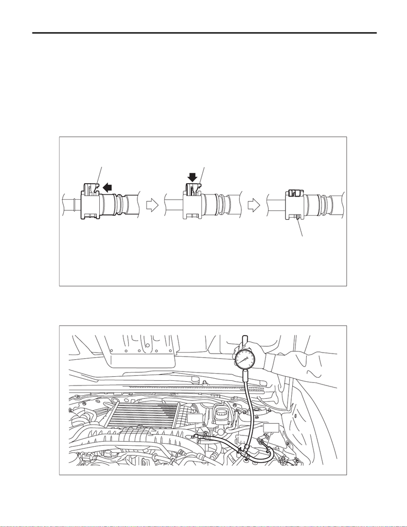

ME(w/o STI)-33

Fuel Pressure

MECHANICAL

(2) Connect the fuel pressure gauge with ST1 and ST2.

CAUTION:

• Check that there is no damage or dust on the quick connector. If necessary, clean the seal surface

of the pipe.

• When connecting the quick connector with slider, make sure to insert it all the way in before lock-

ing the slider.

• When it is difficult to lock the slider, check that the connector is fully inserted.

• After locking the slider, check again that the quick connector is securely connected.

NOTE:

• ST1 is a SUBARU genuine part.

• When connecting the ST2 to the quick connector on the fuel delivery tube, connect as shown in the figure.

ST1 42075AG690 FUEL HOSE

ST2 18471AA000 FUEL PIPE ADAPTER

5) Start the engine.

(a) Slider

FU-07797

(a)

(a)

(a)

ST1

ST2

ME-07902

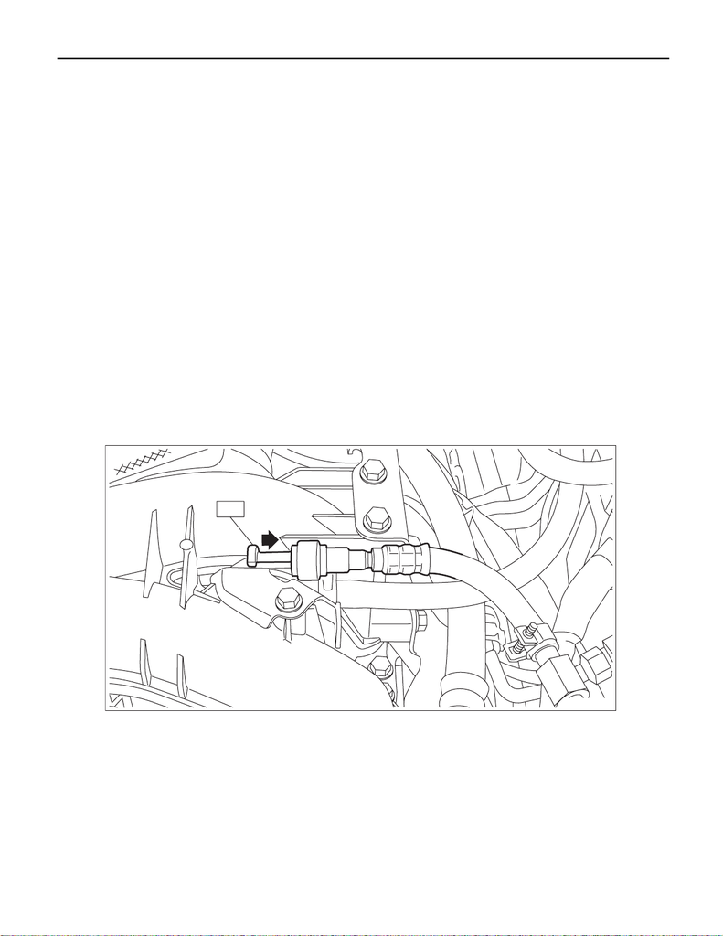

ME(w/o STI)-34

Fuel Pressure

MECHANICAL

6) Check the fuel pressure after warming up the engine.

NOTE:

• The fuel pressure gauge registers 10 to 20 kPa (0.1 to 0.2 kg/cm

2

, 1 to 3 psi) higher than standard values

during high-altitude operations.

• Check or replace the fuel pump and fuel delivery line if the fuel pressure is out of the standard.

Fuel pressure:

Standard

340 — 400 kPa (3.5 — 4.1 kg/cm

2

, 49 — 58 psi)

7) After inspection, install the related parts in the reverse order of removal.

CAUTION:

• Before removing the fuel pressure gauge, release the fuel pressure.

• Be careful not to spill fuel.

• Catch the fuel from hoses and tubes using a container or cloth.

• Check that there is no damage or dust on the quick connector. If necessary, clean the seal surface

of the pipe.

• When connecting the quick connector with slider, make sure to insert it all the way in before lock-

ing the slider.

• When it is difficult to lock the slider, check that the connector is fully inserted.

• After locking the slider, check again that the quick connector is securely connected.

NOTE:

ST1 42075AG690 FUEL HOSE

ME-07903

ST

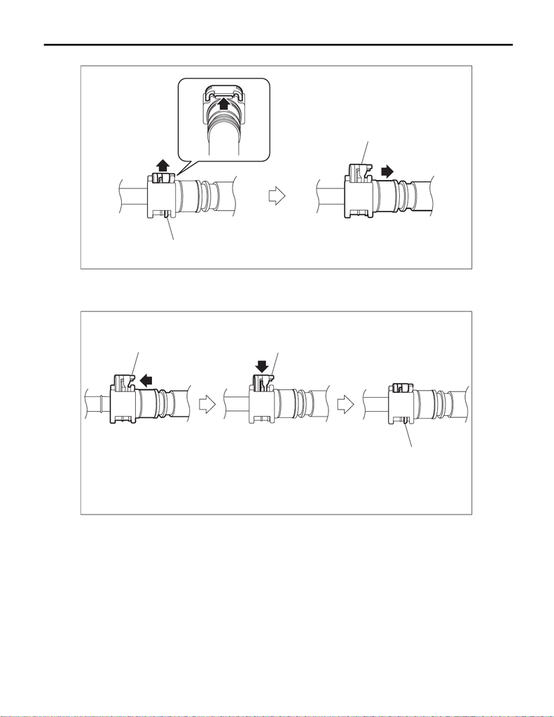

ME(w/o STI)-35

Fuel Pressure

MECHANICAL

• Disconnect the quick connector on the fuel delivery tube as shown in the figure.

• Connect the quick connector on the fuel delivery tube as shown in the figure.

(a) Slider

(a) Slider

FU-07796

(a)

(a)

FU-07797

(a)

(a)

(a)